# Distributed Lag Non-Linear Model (DLNM) Analysis

Daily Precipitation and Asthma ED Visits in NYC (2016–2019)

Minseo (Brenda) Kim

Load libraries

```r
library(dlnm)
library(splines)
library(lubridate)
library(ggplot2)
library(dplyr)
library(readr)
library(tidyr)
```

# Data Preparation

## Load Data

Borough-level asthma ED visits, precipitation, and PM2.5 data (2016–2019).

```r
borough_data <- read_csv("datasets/asthma_precip_pm25_clean.csv")

glimpse(borough_data)
```

```
## Rows: 7,265
## Columns: 5
## $ borough         <chr> "Bronx", "Bronx", "Bronx", "Bronx", "Bronx", "Bronx", …
## $ date            <date> 2016-01-01, 2016-01-02, 2016-01-03, 2016-01-04, 2016-…
## $ asthma_er_count <dbl> 60, 85, 73, 110, 73, 90, 84, 82, 69, 80, 102, 75, 86, …
## $ ppt             <dbl> 0.000000000, 0.000000000, 0.000000000, 0.000000000, 0.…
## $ pm25            <dbl> 5.040000, 8.433333, 9.766667, 5.840000, 11.100000, 14.…
```

```r
summary(borough_data)
```

```
##    borough               date            asthma_er_count       ppt
##  Length:7265        Min.   :2016-01-01   Min.   :  0.00   Min.   : 0.000
##  Class :character   1st Qu.:2016-12-29   1st Qu.: 28.00   1st Qu.: 0.000
##  Mode  :character   Median :2017-12-27   Median : 46.00   Median : 0.000
##                     Mean   :2017-12-27   Mean   : 52.11   Mean   : 3.608
##                     3rd Qu.:2018-12-25   3rd Qu.: 76.00   3rd Qu.: 2.500
##                     Max.   :2019-12-30   Max.   :172.00   Max.   :89.617
##
##       pm25
##  Min.   :-1.300
##  1st Qu.: 4.100
##  Median : 6.167
##  Mean   : 6.884
##  3rd Qu.: 8.900
##  Max.   :28.250
##  NA's   :26
```

## Aggregate to City-Wide

DLNM is fit at the city-wide level. Summing asthma counts and averaging exposure across boroughs per day.

```r
citywide <- borough_data %>%
  mutate(date = as.Date(date)) %>%
  group_by(date) %>%
  summarise(
    asthma_total = sum(asthma_er_count, na.rm = TRUE),
    ppt_mean     = mean(ppt, na.rm = TRUE),
    pm25_mean    = mean(pm25, na.rm = TRUE),
    .groups = "drop"
  ) %>%
  arrange(date)

# Date range and completeness check
cat("Date range:", as.character(min(citywide$date)), "to", as.character(max(citywide$date)), "\n")
```

```
## Date range: 2016-01-01 to 2019-12-30
```

```r
cat("Total days:", nrow(citywide), "\n")
```

```
## Total days: 1453
```

```r
cat("Expected days:", as.numeric(max(citywide$date) - min(citywide$date)) + 1, "\n")
```

```
## Expected days: 1460
```

```r
full_dates <- seq.Date(min(citywide$date), max(citywide$date), by = "day")
missing_dates <- full_dates[!full_dates %in% citywide$date]
cat("Missing dates:", length(missing_dates), "\n")
```

```
## Missing dates: 7
```

## Create Time Variables

Day of week, season, and numeric time index for the long-term trend spline.

```r
citywide <- citywide %>%
  mutate(
    year        = year(date),
    month       = month(date),
    dow         = factor(wday(date, label = TRUE)),
    season      = factor(case_when(
      month %in% c(12, 1, 2)  ~ "Winter",
      month %in% c(3, 4, 5)   ~ "Spring",
      month %in% c(6, 7, 8)   ~ "Summer",
      month %in% c(9, 10, 11) ~ "Fall"
    ), levels = c("Winter", "Spring", "Summer", "Fall")),
    time        = as.numeric(date - min(date))
  )
```

## Temperature Data

```r
# TODO: merge PRISM daily mean temperature
# temp_data <- read_csv("datasets/temperature_data.csv")
```

# Exploratory Data Analysis

## Summary Statistics

```r
citywide %>%
  summarise(
    across(
      c(asthma_total, ppt_mean, pm25_mean),
      list(
        mean   = ~mean(., na.rm = TRUE),
        sd     = ~sd(., na.rm = TRUE),
        median = ~median(., na.rm = TRUE),
        min    = ~min(., na.rm = TRUE),
        max    = ~max(., na.rm = TRUE)
      ),
      .names = "{.col}_{.fn}"
    )
  ) %>%
  pivot_longer(everything(), names_to = "stat", values_to = "value") %>%
  print(n = Inf)
```

```
## # A tibble: 15 × 2
##    stat                    value
##    <chr>                   <dbl>
##  1 asthma_total_mean   261.
##  2 asthma_total_sd      50.6
##  3 asthma_total_median 256
##  4 asthma_total_min    142
##  5 asthma_total_max    537
##  6 ppt_mean_mean         3.61
##  7 ppt_mean_sd           8.10
##  8 ppt_mean_median       0.00214
##  9 ppt_mean_min          0
## 10 ppt_mean_max         86.1
## 11 pm25_mean_mean        6.89
## 12 pm25_mean_sd          3.60
## 13 pm25_mean_median      6.14
## 14 pm25_mean_min         0.3
## 15 pm25_mean_max        25.5
```

## Precipitation Distribution

Key percentiles and histogram with 95th percentile marked.

```r
precip_quantiles <- quantile(citywide$ppt_mean,
                              probs = c(0.25, 0.50, 0.75, 0.90, 0.95, 0.99),
                              na.rm = TRUE)
cat("Precipitation percentiles (mm):\n")
```

```
## Precipitation percentiles (mm):
```

```r
print(round(precip_quantiles, 2))
```

```
##   25%   50%   75%   90%   95%   99%
##  0.00  0.00  2.69 12.46 20.56 37.64
```

```r
cat("\nZero-precipitation days:",
    round(mean(citywide$ppt_mean == 0, na.rm = TRUE) * 100, 1), "%\n")
```

```
##
## Zero-precipitation days: 45.7 %
```

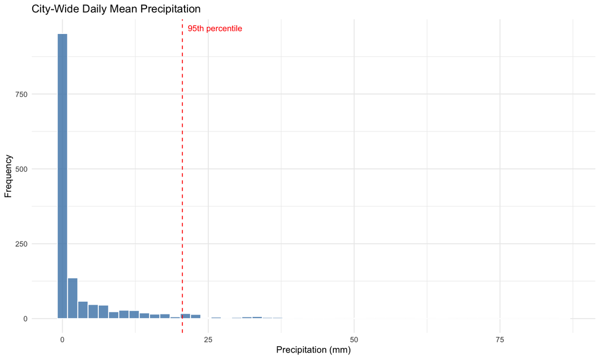

```r
ggplot(citywide, aes(x = ppt_mean)) +
  geom_histogram(bins = 50, fill = "steelblue", color = "white", alpha = 0.8) +
  geom_vline(xintercept = precip_quantiles["95%"], linetype = "dashed", color = "red") +
  annotate("text", x = precip_quantiles["95%"], y = Inf, label = "95th percentile",
           vjust = 2, hjust = -0.1, color = "red", size = 3.5) +
  labs(title = "City-Wide Daily Mean Precipitation",
       x = "Precipitation (mm)", y = "Frequency") +
  theme_minimal()
```

The precipitation distribution is extremely right-skewed with a large spike at 0 mm (median 0; ~45.7% of days), a modest amount of light precipitation (75th percentile 2.69 mm), and a sparse extreme tail; the dashed red line marks the 95th percentile (20.56 mm), highlighting that estimates for very heavy rain (>20-80mm) are based on sparse data in the tail.

## Cross-Correlation

CCF between precipitation and asthma ED visits (up to 21-day lag).

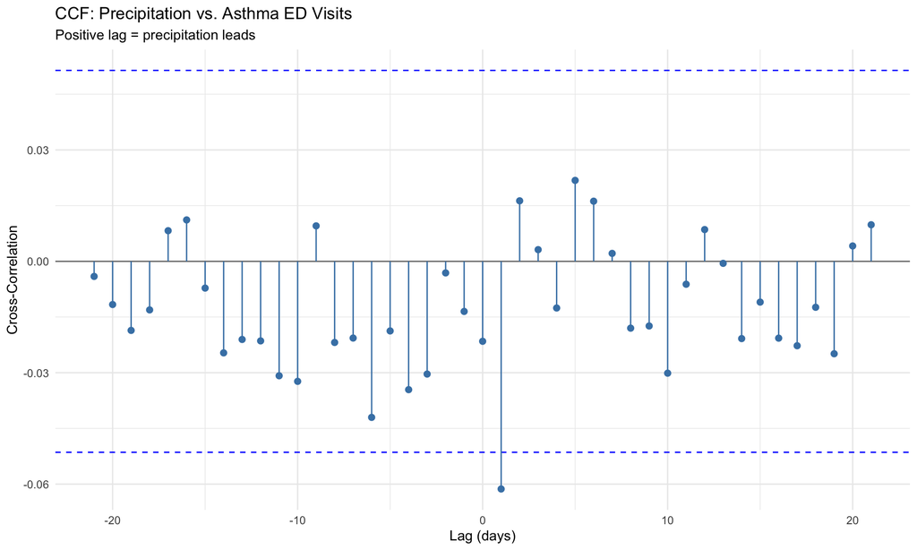

```r
ccf_result <- ccf(citywide$ppt_mean, citywide$asthma_total,
                   lag.max = 21, plot = FALSE)

ccf_df <- data.frame(lag = ccf_result$lag, acf = ccf_result$acf)

ggplot(ccf_df, aes(x = lag, y = acf)) +
  geom_hline(yintercept = 0, color = "gray50") +
  geom_hline(yintercept = c(-1, 1) * qnorm(0.975) / sqrt(nrow(citywide)),
             linetype = "dashed", color = "blue") +
  geom_segment(aes(xend = lag, yend = 0), color = "steelblue") +
  geom_point(color = "steelblue", size = 2) +
  labs(title = "CCF: Precipitation vs. Asthma ED Visits",
       subtitle = "Positive lag = precipitation leads",
       x = "Lag (days)", y = "Cross-Correlation") +
  theme_minimal()
```

Cross-correlations are near zero at most lags (within the plotted significance bounds), implying weak linear lead–lag association in raw series. There is one visibly stronger negative correlation appears around a short positive lag (precipitation leading by ~1 day), but its magnitude remains small in absolute terms. => No strong linear lead-lag relationship between daily rain and asthma ED visits in the raw data.

## Autocorrelation of Asthma ED Visits

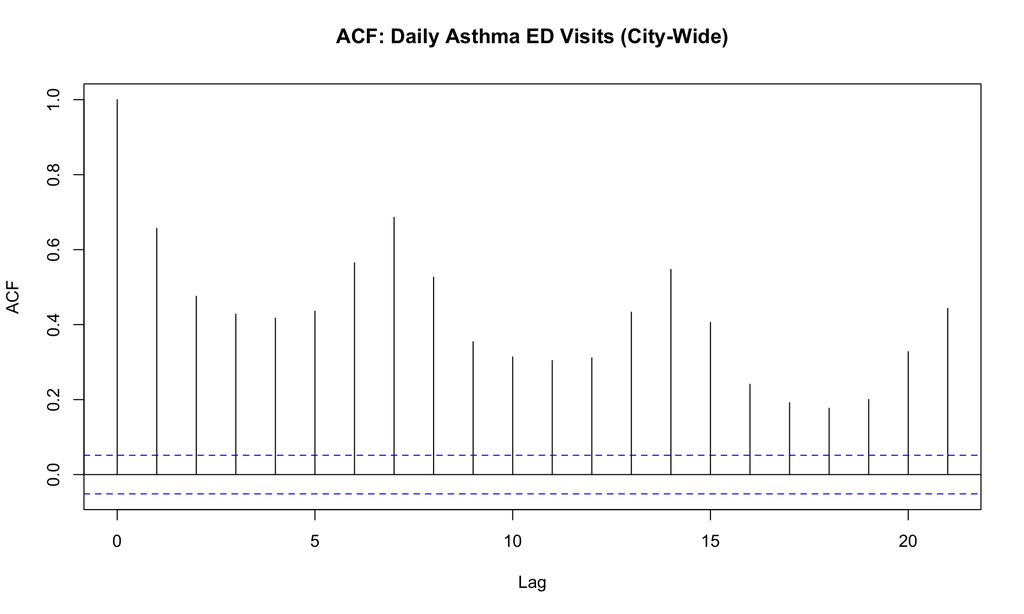

```r
acf(citywide$asthma_total, lag.max = 21,
    main = "ACF: Daily Asthma ED Visits (City-Wide)")
```

Autocorrelation is strongly positive across many lags with a slow decay and apparent weekly structure (elevations around ~7, ~14, ~21 days). It confirms substantial temporal dependence (day-of-week and longer-term patterns), which the DLNM model correctly controls for using the time spline, DOW, and season terms.

# DLNM Model

## Cross-Basis

Natural cubic splines for exposure (3 df) and lag (4 df), max lag = 14 days.

```r
cb_precip <- crossbasis(
  citywide$ppt_mean,
  lag    = 14,
  argvar = list(fun = "ns", df = 3),
  arglag = list(fun = "ns", df = 4)
)

summary(cb_precip)
```

```
## CROSSBASIS FUNCTIONS
## observations: 1453
## range: 0 to 86.08477
## lag period: 0 14
## total df:  12
##
## BASIS FOR VAR:
## fun: ns
## knots: 0.1288668 1.030935
## intercept: FALSE
## Boundary.knots: 0 86.08477
##
## BASIS FOR LAG:
## fun: ns
## knots: 4.666667 9.333333
## intercept: TRUE
## Boundary.knots: 0 14
```

## Primary Model

Quasi-Poisson GLM: `log(E[Y]) = α + cb(precip, lag 0–14) + ns(time, 7df/yr) + DOW + season`. Temperature spline to be added.

```r
n_years <- as.numeric(max(citywide$date) - min(citywide$date)) / 365.25
time_df <- round(7 * n_years)

model_primary <- glm(
  asthma_total ~ cb_precip +
    ns(time, df = time_df) +
    # ns(temp_mean, df = 6) +    # TODO: add temperature
    dow +
    season,
  family = quasipoisson(link = "log"),
  data   = citywide
)

summary(model_primary)
```

```
##
## Call:
## glm(formula = asthma_total ~ cb_precip + ns(time, df = time_df) +
##     dow + season, family = quasipoisson(link = "log"), data = citywide)
##
## Coefficients:
##                            Estimate Std. Error t value Pr(>|t|)
## (Intercept)               5.6070143  0.0582635  96.235  < 2e-16 ***
## cb_precipv1.l1           -0.0506395  0.0299335  -1.692 0.090922 .
## cb_precipv1.l2            0.0201807  0.0281721   0.716 0.473904
## cb_precipv1.l3           -0.0670187  0.0259167  -2.586 0.009813 **
## cb_precipv1.l4           -0.0149824  0.0255017  -0.588 0.556961
## cb_precipv2.l1            0.0264710  0.0317029   0.835 0.403878
## cb_precipv2.l2           -0.0208145  0.0302315  -0.689 0.491251
## cb_precipv2.l3            0.0221111  0.0280379   0.789 0.430472
## cb_precipv2.l4           -0.0016186  0.0272038  -0.059 0.952564
## cb_precipv3.l1            0.0905420  0.0733898   1.234 0.217519
## cb_precipv3.l2           -0.0851490  0.0696556  -1.222 0.221753
## cb_precipv3.l3            0.0913742  0.0630221   1.450 0.147319
## cb_precipv3.l4           -0.0347257  0.0633753  -0.548 0.583823
## ns(time, df = time_df)1  -0.1289165  0.0683721  -1.886 0.059569 .
## ns(time, df = time_df)2   0.0852273  0.0787344   1.082 0.279233
## ns(time, df = time_df)3  -0.2569269  0.0792089  -3.244 0.001208 **
## ns(time, df = time_df)4   0.0785129  0.0748369   1.049 0.294306
## ns(time, df = time_df)5   0.1671415  0.0757027   2.208 0.027417 *
## ns(time, df = time_df)6   0.0480364  0.0686028   0.700 0.483913
## ns(time, df = time_df)7  -0.1693298  0.0686140  -2.468 0.013712 *
## ns(time, df = time_df)8  -0.0070287  0.0786195  -0.089 0.928776
## ns(time, df = time_df)9   0.1989427  0.0720833   2.760 0.005858 **
## ns(time, df = time_df)10 -0.5261318  0.0841462  -6.253 5.36e-10 ***
## ns(time, df = time_df)11  0.0579017  0.0727163   0.796 0.426012
## ns(time, df = time_df)12 -0.0003485  0.0800103  -0.004 0.996525
## ns(time, df = time_df)13 -0.0269676  0.0688194  -0.392 0.695222
## ns(time, df = time_df)14  0.0041775  0.0685576   0.061 0.951421
## ns(time, df = time_df)15 -0.1022717  0.0785616  -1.302 0.193200
## ns(time, df = time_df)16  0.3289988  0.0715537   4.598 4.66e-06 ***
## ns(time, df = time_df)17 -0.5666838  0.0842958  -6.723 2.60e-11 ***
## ns(time, df = time_df)18  0.1909169  0.0720060   2.651 0.008107 **
## ns(time, df = time_df)19  0.1990691  0.0775344   2.567 0.010347 *
## ns(time, df = time_df)20 -0.0922123  0.0677223  -1.362 0.173537
```

[output cut: 13 more lines]

```
## dow^6                    -0.0172424  0.0079021  -2.182 0.029277 *
## seasonSpring              0.0495762  0.0227560   2.179 0.029529 *
## seasonSummer             -0.1181211  0.0263925  -4.476 8.24e-06 ***
## seasonFall               -0.0558816  0.0233593  -2.392 0.016877 *
## ---
## Signif. codes:  0 '***' 0.001 '**' 0.01 '*' 0.05 '.' 0.1 ' ' 1
##
## (Dispersion parameter for quasipoisson family taken to be 3.434041)
##
##     Null deviance: 13851.6  on 1438  degrees of freedom
## Residual deviance:  4757.5  on 1389  degrees of freedom
##   (14 observations deleted due to missingness)
## AIC: NA
##
## Number of Fisher Scoring iterations: 4
```

```r
cat("\nDispersion parameter:", summary(model_primary)$dispersion, "\n")
```

```
##
## Dispersion parameter: 3.434041
```

## DLNM Predictions

Centering at 0 mm (no rain) as the reference.

```r
pred_primary <- crosspred(
  cb_precip,
  model_primary,
  at  = seq(0, max(citywide$ppt_mean, na.rm = TRUE), length.out = 100),
  cen = 0
)
```